# Left Behind: The Silent Crisis of Early Childhood Neglect

A UNICEF Data Report on Child Supervision and Access to Early Education

Author

Kavya Moturu

Published

April 14, 2026

## The Invisible Emergency

Every day, millions of children under the age of five wake up in a world where **no responsible adult is watching over them**. Left alone or worse, in the care of another young child they face risks that no infant should ever know. Meanwhile, across the same globe, countless toddlers are denied access to **early childhood education programmes** that could set the course of their entire lives.

This report draws on UNICEF data collected across more than 100 countries to illuminate two deeply connected crises: the **widespread unsupervised care of young children**, and the **unequal access to early childhood education (ECE)**. Together, they reveal a world that is failing its youngest and most vulnerable members not through malice, but through poverty, inequality, and neglect.

> *“The first five years have so much to do with how the next 80 turn out.”* — Bill Gates

## Understanding the Data

This analysis draws on three UNICEF datasets:

- **Indicator 1** — Percentage of children under age 5 left alone or under the supervision of a child younger than 10, for more than one hour, at least once in the past week
- **Indicator 2** — Percentage of children aged 36–59 months attending an early childhood education programme
- **Metadata** — Country-level economic and demographic indicators including GDP per capita, life expectancy, and birth rate

Together, these datasets span **over 125 countries** and multiple decades, offering a powerful lens through which to examine child welfare globally.

## Where Are Children Being Left Alone?

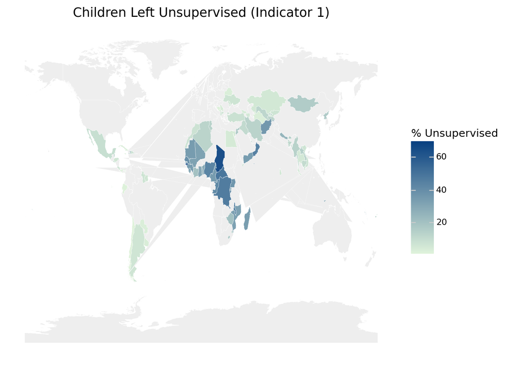

Figure 1: Share of children under 5 left unsupervised for 1+ hour per week, by country (most recent year)

```python
# Process UNICEF Indicator 1 for the map
map_data = (
    ind1
    .filter(pl.col("sex") == "Total")
    .sort("time_period", descending=True)
    .unique(subset=["alpha_3_code"], keep="first")
    .select(["alpha_3_code", "obs_value"])
    .rename({"obs_value": "unsupervised_pct"})
)

# Load the local world map file
import geopandas as gpd
world = gpd.read_file("world.geojson")

# Standardize column name based on diagnostic output
possible_iso_cols = ['ISO3166-1-Alpha-3', 'ISO_A3', 'iso_a3', 'id', 'ISO_A3_EH', 'GU_A3', 'adm0_a3']
found = False
for col in possible_iso_cols:
    if col in world.columns:
        world = world.rename(columns={col: 'alpha_3_code'})
        found = True
        break

map_pd = map_data.to_pandas()
world_merged = world.merge(map_pd, on="alpha_3_code", how="left")

# Preparation for Plotnine map
from shapely.geometry import mapping
import json
import pandas as pd

def gdf_to_plotnine(gdf, id_col="alpha_3_code"):
    rows = []
    for _, row in gdf.iterrows():
        if row.geometry is None: continue
        geom = row.geometry
        if geom.geom_type == "Polygon":
            polys = [geom]
        elif geom.geom_type == "MultiPolygon":
            polys = list(geom.geoms)
        else:
            continue
        for pi, poly in enumerate(polys):
            coords = list(poly.exterior.coords)
            for x, y in coords:
                rows.append({"x": x, "y": y, "group": f"{row[id_col]}_{pi}", "val": row["unsupervised_pct"]})
    return pd.DataFrame(rows)

map_df_plot = gdf_to_plotnine(world_merged)

from plotnine import *
p_map = (
    ggplot(map_df_plot, aes(x="x", y="y", group="group", fill="val"))
    + geom_polygon(color="white", size=0.1)
    + scale_fill_gradient(low="#e0f3db", high="#084081", na_value="#eeeeee", name="% Unsupervised")
    + theme_void()
    + labs(title="Children Left Unsupervised (Indicator 1)")
)
p_map.draw()
```

**Key observation:** Sub-Saharan Africa carries the heaviest burden. Countries like **Guinea-Bissau (70.1%)**, **Chad (64.2%)**, and the **Democratic Republic of Congo (46.6%)** report that nearly half or more of all young children are left without adequate supervision each week. This is not a marginal phenomenon — it is a structural reality of poverty.

## The Countries Failing Their Youngest

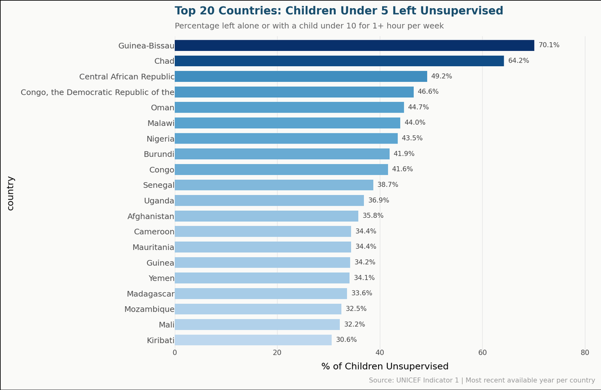

Figure 2: Top 20 countries by percentage of unsupervised children under 5 (most recent year, Total)

```python
bar_data = (
    ind1
    .filter(pl.col("sex") == "Total")
    .sort("time_period", descending=True)
    .unique(subset=["country"], keep="first")
    .sort("obs_value", descending=True)
    .head(20)
    .to_pandas()
)

bar_data["country"] = pd.Categorical(
    bar_data["country"],
    categories=bar_data.sort_values("obs_value")["country"].tolist(),
    ordered=True
)

p_bar = (
    ggplot(bar_data, aes(x="country", y="obs_value", fill="obs_value"))
    + geom_col(width=0.7, show_legend=False)
    + geom_text(
        aes(label="obs_value.round(1).astype(str) + '%'"),
        ha="left", nudge_y=0.8, size=8, color="#444444"
    )
    + scale_fill_gradientn(
        colors=["#bdd7ee", "#5ba4cf", "#1a6fa8", "#08306b"]
    )
    + coord_flip()
    + scale_y_continuous(limits=[0, 82], expand=(0, 0))
    + labs(
        title="Top 20 Countries: Children Under 5 Left Unsupervised",
        subtitle="Percentage left alone or with a child under 10 for 1+ hour per week",
        x=None,
        y="% of Children Unsupervised",
        caption="Source: UNICEF Indicator 1 | Most recent available year per country"
    )
    + theme_minimal()
    + theme(
        plot_title=element_text(size=13, weight="bold", color="#1a4f6e"),
        plot_subtitle=element_text(size=9.5, color="#666666"),
        plot_caption=element_text(size=8, color="#999999"),
        axis_text_y=element_text(size=9.5),
        axis_text_x=element_text(size=8.5),
        panel_grid_major_y=element_blank(),
        panel_grid_minor_x=element_blank(),
        panel_grid_major_x=element_line(color="#ebebeb"),
        figure_size=(10, 6.5),
        plot_background=element_rect(fill="#fafaf8", color=None),
    )
)
p_bar.draw()
```

This is not simply a cultural difference. It is the direct consequence of economic precarity: when parents must work long hours with no paid leave, no state-funded childcare, and no extended family nearby, young children are left to fend for themselves.

## Education as the Antidote: The ECE Attendance Gap

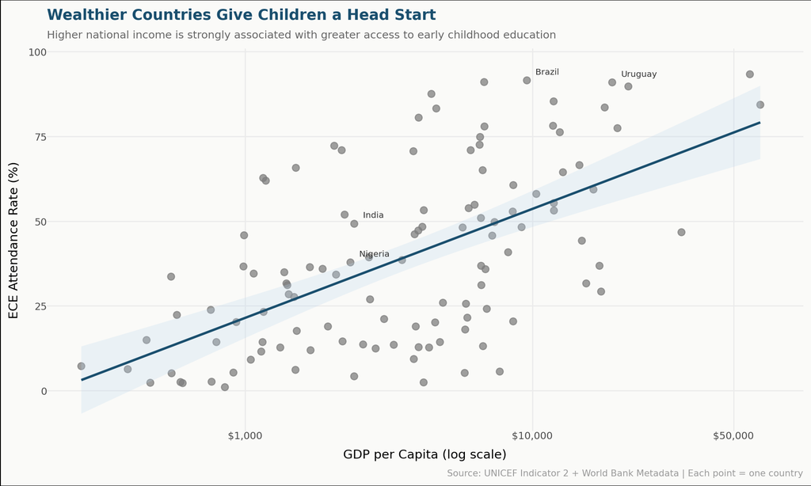

Figure 3: GDP per capita vs. ECE attendance rate, with linear regression line

```python
# Merge indicator 2 (Total) with most recent metadata per country
ece_total = (
    ind2
    .filter(pl.col("sex") == "Total")
    .sort("time_period", descending=True)
    .unique(subset=["alpha_3_code"], keep="first")
    .select(["country", "alpha_3_code", "obs_value"])
    .rename({"obs_value": "ece_rate"})
)

meta_recent = (
    meta
    .sort("year", descending=True)
    .unique(subset=["alpha_3_code"], keep="first")
    .select([
        "alpha_3_code",
        "GDP per capita (constant 2015 US$)",
        "Life expectancy at birth, total (years)"
    ])
    .rename({
        "GDP per capita (constant 2015 US$)": "gdp_per_capita",
        "Life expectancy at birth, total (years)": "life_expectancy"
    })
)

scatter_df = (
    ece_total
    .join(meta_recent, on="alpha_3_code", how="inner")
    .filter(pl.col("gdp_per_capita").is_not_null())
    .filter(pl.col("ece_rate").is_not_null())
    .to_pandas()
)

# Log-transform GDP for better visual spread
scatter_df["log_gdp"] = np.log10(scatter_df["gdp_per_capita"])

# Label a few notable countries
label_countries = ["Afghanistan", "Nigeria", "India", "Brazil", "Germany", "China", "Ethiopia", "Uruguay", "United States"]
scatter_df["label"] = scatter_df["country"].where(scatter_df["country"].isin(label_countries), "")

p_scatter = (
    ggplot(scatter_df, aes(x="log_gdp", y="ece_rate"))
    + geom_point(aes(color="life_expectancy"), size=3, alpha=0.75)
    + geom_smooth(method="lm", color="#1a4f6e", fill="#bdd7ee", alpha=0.25, size=1.2)
    + geom_text(
        aes(label="label"),
        size=7.5, color="#333333", nudge_y=2.5, nudge_x=0.03, ha="left"
    )
    + scale_color_gradientn(
        colors=["#f9c74f", "#43aa8b", "#277da1"],
        name="Life Expectancy\n(years)"
    )
    + scale_x_continuous(
        breaks=[2, 3, 4, 4.7],
        labels=["$100", "$1,000", "$10,000", "$50,000"],
        name="GDP per Capita (log scale)"
    )
    + labs(
        title="Wealthier Countries Give Children a Head Start",
        subtitle="Higher national income is strongly associated with greater access to early childhood education",
        y="ECE Attendance Rate (%)",
        caption="Source: UNICEF Indicator 2 + World Bank Metadata | Each point = one country"
    )
    + theme_minimal()
    + theme(
        plot_title=element_text(size=13, weight="bold", color="#1a4f6e"),
        plot_subtitle=element_text(size=9.5, color="#666666"),
        plot_caption=element_text(size=8, color="#999999"),
        panel_grid_minor=element_blank(),
        panel_grid_major=element_line(color="#ebebeb"),
        figure_size=(10, 6),
        plot_background=element_rect(fill="#fafaf8", color=None),
    )
)
p_scatter.draw()
```

## A World Changing — But Not Fast Enough

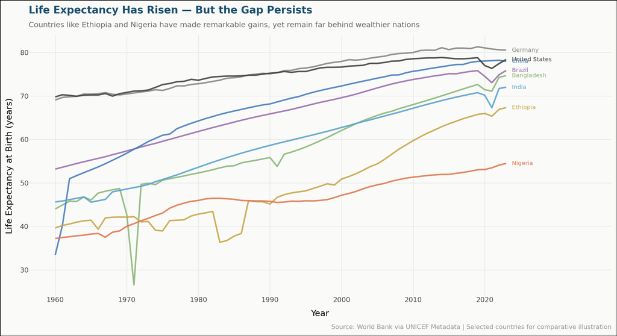

Figure 4: Life expectancy over time across selected countries (1960–2023)

```python
focus_countries = ["Nigeria", "India", "Brazil", "China", "Germany", "United States", "Ethiopia", "Bangladesh"]

ts_df = (
    meta
    .filter(pl.col("country").is_in(focus_countries))
    .filter(pl.col("Life expectancy at birth, total (years)").is_not_null())
    .select([
        "country", "year",
        pl.col("Life expectancy at birth, total (years)").alias("life_expectancy")
    ])
    .to_pandas()
)

# Colour palette — distinct but soft
country_colors = {
    "Nigeria":        "#e07b54",
    "Ethiopia":       "#c9a84c",
    "Bangladesh":     "#8db87a",
    "India":          "#5ba4cf",
    "China":          "#4a7fc1",
    "Brazil":         "#9b72b0",
    "Germany":        "#888888",
    "United States":  "#444444",
}

# End-of-line labels
labels_df = (
    ts_df.sort_values("year")
         .groupby("country", as_index=False)
         .last()
)

p_ts = (
    ggplot(ts_df, aes(x="year", y="life_expectancy", color="country", group="country"))
    + geom_line(size=1.1, alpha=0.9)
    + geom_text(
        data=labels_df,
        mapping=aes(x="year", y="life_expectancy", label="country"),
        nudge_x=0.8, size=7.5, ha="left"
    )
    + scale_color_manual(values=country_colors, guide=None)
    + scale_x_continuous(
        breaks=[1960, 1970, 1980, 1990, 2000, 2010, 2020],
        limits=[1960, 2034]
    )
    + scale_y_continuous(breaks=range(30, 90, 10))
    + labs(
        title="Life Expectancy Has Risen — But the Gap Persists",
        subtitle="Countries like Ethiopia and Nigeria have made remarkable gains, yet remain far behind wealthier nations",
        x="Year",
        y="Life Expectancy at Birth (years)",
        caption="Source: World Bank via UNICEF Metadata | Selected countries for comparative illustration"
    )
    + theme_minimal()
    + theme(
        plot_title=element_text(size=13, weight="bold", color="#1a4f6e"),
        plot_subtitle=element_text(size=9.5, color="#666666"),
        plot_caption=element_text(size=8, color="#999999"),
        panel_grid_minor=element_blank(),
        panel_grid_major=element_line(color="#ebebeb"),
        figure_size=(11, 6),
        plot_background=element_rect(fill="#fafaf8", color=None),
    )
)
p_ts.draw()
```

The time series reveals a **story of progress shadowed by persistent inequality**. Since 1960, life expectancy has risen in every country shown a testament to advances in medicine, sanitation, and nutrition. Ethiopia climbed from under 40 years in 1960 to over 67 years today. Bangladesh made similarly dramatic gains.

## Conclusions: What the Data Demands

The evidence is unambiguous:

1. **Unsupervised early childhood is concentrated in the world’s poorest countries**, particularly Sub-Saharan Africa, where structural poverty leaves parents with no viable childcare options.
2. **Early childhood education attendance is directly tied to national wealth** — not because low-income families value education less, but because they lack the infrastructure and financial means to access it.
3. **Development indicators improve together** — countries with higher GDP per capita show better life expectancy, higher ECE rates, and lower rates of child neglect. Poverty is the common thread.

*Report produced using UNICEF open data. Analysis conducted in Python using Polars and Plotnine. Rendered with Quarto.*